# Lab 10

Rahmat Ashari

Apr 01, 2020

# Task 1, Working Directory

```r
getwd()
```

```
## [1] "C:/Users/ra/Documents/StatClass/Lab 10"
```

# Task 2, Binomial

Here we define a function to approximate the maximum likelihood from a sample by using a grid approximation.

```r
mymaxlik=function(lfun,x,param,...){

  np=length(param)
  z=outer(x,param,lfun) # A
  y=apply(z,2,sum)
  plot(param,y,col="Blue",type="l",lwd=2,...)
  i=max(which(y==max(y))) # B
  abline(v=param[i],lwd=2,col="Red")
  points(param[i],y[i],pch=19,cex=1.5,col="Black")
  axis(3,param[i],round(param[i],2))
  ifelse(i-3>=1 & i+2<=np, slope<-(y[(i-2):(i+2)]-y[(i-3):(i+1)])/(param[(i-2):(i+2)]-param[(i-3):(i+1)]),slope<-"NA")

  return(list(i=i,parami=param[i],yi=y[i],slope=slope))

}
```

To examine what *line A* does, we can execute the function below

```r
outer(1:4,5:10,function(x,y) paste(x,y,sep=" "))
```

```
##      [,1]  [,2]  [,3]  [,4]  [,5]  [,6]
## [1,] "1 5" "1 6" "1 7" "1 8" "1 9" "1 10"
## [2,] "2 5" "2 6" "2 7" "2 8" "2 9" "2 10"
## [3,] "3 5" "3 6" "3 7" "3 8" "3 9" "3 10"
## [4,] "4 5" "4 6" "4 7" "4 8" "4 9" "4 10"
```

The `outer()` function takes the first parameter as a row element and the second parameter as column element to create a matrix. The values of each element in the matrix are computed using the given function.

Meanwhile, *Line B* find the largest index that corresponds to the greatest value found in vector *y*

We can test the above function for a 8-experiment binomial with 20 trials with equal p. By imposing independence for each experiment, this can be written mathematically

$$p(y) = \binom{20}{y_1}p^{y_1}q^{20-y_1}\ \binom{20}{y_2}p^{y_2}q^{20-y_2} \ ... \ \binom{20}{y_8}p^{y_8}q^{20-y_1}$$
$$p(y) = \prod_{i = 1}^{8}\binom{20}{y_i}p^{y_i}q^{20 - y_i}$$

This expression can be done in R as follows:

```r
y.list = c(y1,y2,y3,y4,y5,y6,y7,y8)

a = 1

for (i in y.list){
  p = dbinom(i, 20, p) * a
  a = p
}

print(a)
```

Now, we can use the `mymaxlink()` to find the maximum likelihood estimate given a list of ys as shown below.

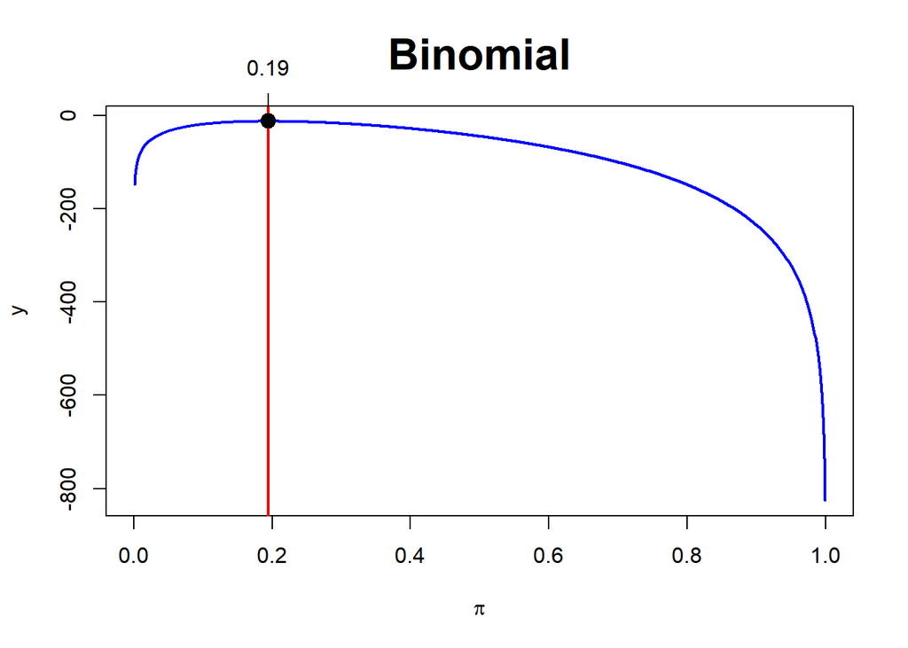

```
## $i
## [1] 195
##
## $parami
## [1] 0.1941942
##
## $yi
## [1] -12.78734
##
## $slope
## [1]  2.12579310  1.08781082  0.05802047 -0.96371372 -1.97752478
```

```r
logbin=function(x,param) log(dbinom(x,prob=param,size=20))

x.list = c(3,3,4,3,4,5,5,4)

mymaxlik(x=x.list,param=seq(0,1,length=1000),lfun=logbin,xlab=expression(pi),main="Binomial",cex.main=2)
```

# Task 3, Poisson

In this section we will use `mymaxlik()` and `myNRML()` to estimate $\lambda$ for a poisson distribution with ys given in the chunk below (denoted by x.list3)

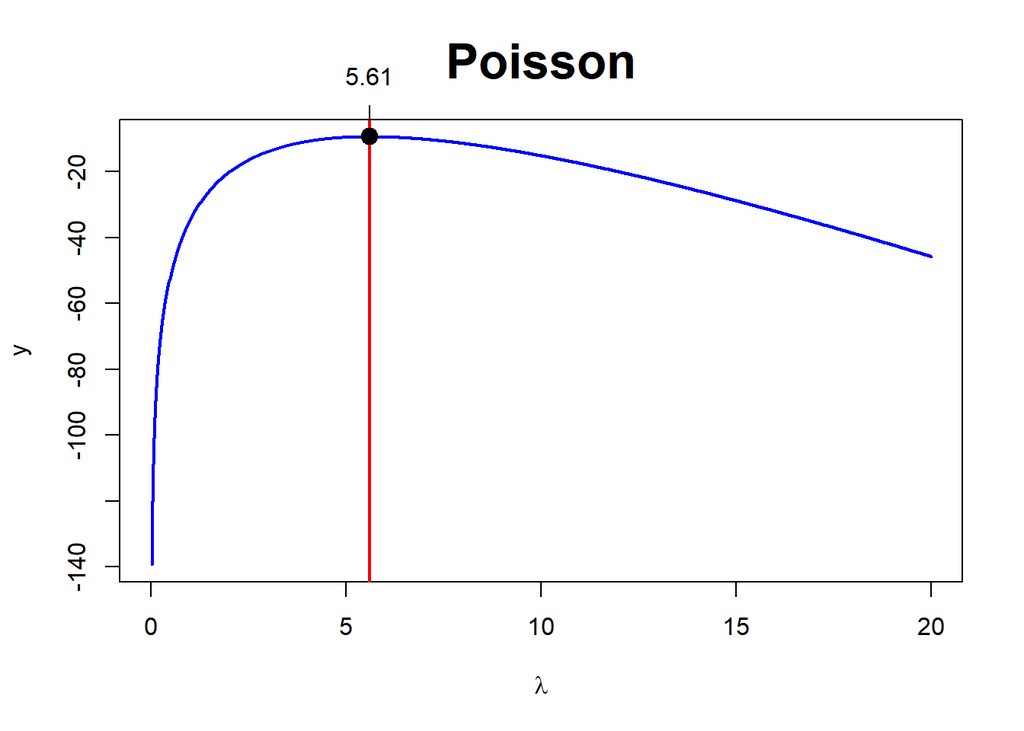

```
## $i
## [1] 281
##
## $parami
## [1] 5.605606
##
## $yi
## [1] -9.411759
##
## $slope
## [1]  0.040005454  0.021908448  0.003940937 -0.013898462 -0.031611116
```

```r
x.list3 = c(4,6,7,6,5)

logpoiss=function(x,param) log(dpois(x,lambda=param))

mymaxlik(x=x.list3, param=seq(0,20,length=1000),lfun=logpoiss,xlab=expression(lambda),main="Poisson",cex.main=2)
```

The algebraic expression for the log likelihood is

$$p(y) = \frac{\lambda^{y_1}e^{-\lambda}}{y_1!} \ \frac{\lambda^{y_2}e^{-\lambda}}{y_2!} \ ... \ \frac{\lambda^{y_n}e^{-\lambda}}{y_n!}$$
$$p(y) = \frac{\lambda^{\sum_{i=1}^{n}y_i} \ e^{-n\lambda}}{\prod_{i=1}^{n}y_i!}$$
$$ln(p(y)) = ln(\lambda) \sum_{i=1}^{n}(y_i) - n\lambda - \sum_{i=1}^{n}(y_i!)$$

In addition to using the grid approximation, we can also use Newton Raphson numerical method.

```r
myNRML=function(x0,delta=0.001,llik,xrange,parameter="param"){

  f=function(x) (llik(x+delta)-llik(x))/delta
  fdash=function(x) (f(x+delta)-f(x))/delta
  d=1000
  i=0
  x=c()
  y=c()
  x[1]=x0
  y[1]=f(x[1])
  while(d > delta & i<100){
    i=i+1
    x[i+1]=x[i]-f(x[i])/fdash(x[i])
    y[i+1]=f(x[i+1])
    d=abs(y[i+1])
  }
  layout(matrix(1:2,nr=1,nc=2,byrow=TRUE),width=c(1,2))
  curve(llik(x), xlim=xrange,xlab=parameter,ylab="log Lik",main="Log Lik")
  curve(f(x),xlim=xrange,xaxt="n", xlab=parameter,ylab="derivative",main=  "Newton-Raphson Algorithm \n on the derivative")
  points(x,y,col="Red",pch=19,cex=1.5)
  axis(1,x,round(x,2),las=2)
  abline(h=0,col="Red")

  segments(x[1:(i-1)],y[1:(i-1)],x[2:i],rep(0,i-1),col="Blue",lwd=2)
  segments(x[2:i],rep(0,i-1),x[2:i],y[2:i],lwd=0.5,col="Green")

  list(x=x,y=y)
}
```

Now we can use the previous input to approximate lambda using `myNRML()`

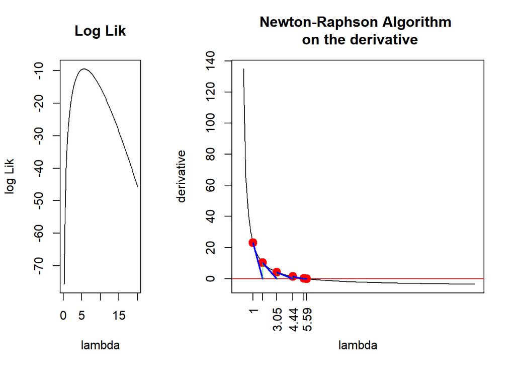

```
## $x
## [1] 1.000000 1.821147 3.048672 4.436748 5.359232 5.589568 5.599970 5.600000
##
## $y
## [1]  2.299999e+01  1.037492e+01  4.184327e+00  1.310927e+00  2.246292e-01
## [6]  9.330797e-03  2.633627e-05 -3.019807e-08
```

```r
myNRML(x0=1,delta=0.000001,llik=function(x) log(dpois(4,x)*dpois(6,x)*dpois(7,x)*dpois(6,x)*dpois(5,x)),xrange=c(0,20),parameter="lambda" )
```

# Task 4, Biased Coin

In this case, we have two binomial experiments. The first experiment has 6 trials with 2 heads, while the other one has 10 trials with 4 heads. Denoting p = chance of head, we can use `mymaxlikg()` to approximate for p.

Joint density has one unknown common parameter but different values for the other parameters

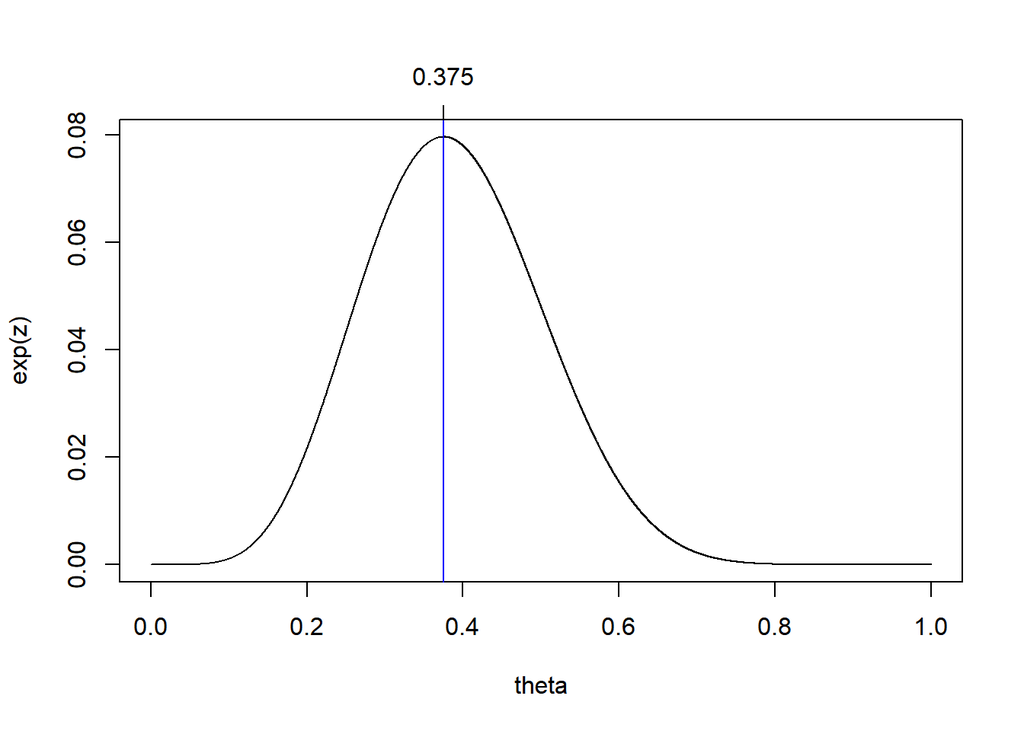

```
## [1] 0.3750375
```

```r
logbin2=function(theta){log(dbinom(2,prob=theta,size=6)) + log(dbinom(4,prob=theta,size=10))}

mymaxlikg=function(lfun="logbin2",theta) { # default log lik is a combination bin
nth=length(theta)  # nu. of valuse used in theta
thmat=matrix(theta,nr=nth,nc=1,byrow=TRUE) # Matrix of theta
z=apply(thmat,1,lfun) # z holds the log lik values
zmax=max(which(z==max(z)))  # finding the INDEX of the max lik
plot(theta,exp(z),type="l") # plot of lik
abline(v=theta[zmax],col="Blue")   #  verical line through max
axis(3,theta[zmax],round(theta[zmax],4))  # one tick on the third axis
theta[zmax]   # theta corresponding to max lik
}

mymaxlikg(theta=seq(0,1,length=10000))
```

# Task 5, Joint Between Poisson and Binomial

Suppose we have $p(y_1,y_2|\theta_1\theta_2) = bin(y_1|\theta_1)poiss(y_2|\theta_2)$, we can write the expression for the log likelihood as follows:

$$ln( p(y_1,y_2)) = ln(\binom{n}{y_1}p^{y_1}q^{n-y_1} \ \frac{\lambda^{y_2}e^{-\lambda}}{y_2!})$$
$$ln( p(y_1,y_2)) = ln(\binom{n}{y_1}) + y_1ln(p) + (n-y_1)ln(q) + y_2ln(\lambda) -\lambda - ln(y_2!)$$

We can approximate $\theta_1$ and $\theta_2$ through a function `mymaxlikg2()`!

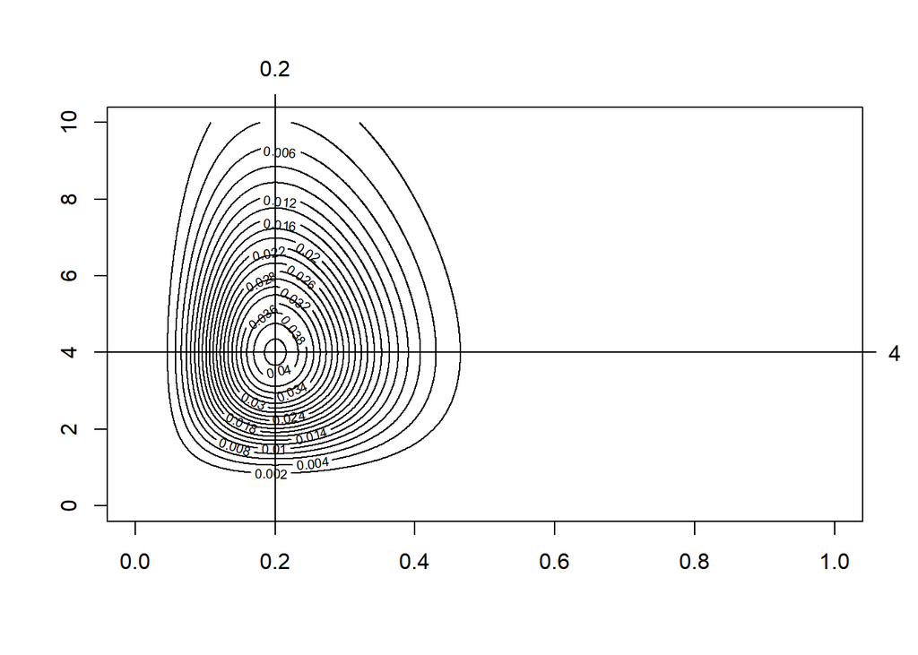

```
## $th1est
## [1] 0.2002002
##
## $th2est
## [1] 4.004004
```

```r
logbinpois=function(theta1,theta2) log(dbinom(4,size=20,prob=theta1)) +  log(dpois(4,lambda=theta2))

maxlikg2=function(theta1,theta2,lfun="logbinpois",...){
n1=length(theta1)
n2=length(theta2)
z=outer(theta1,theta2,lfun)
contour(theta1,theta2,exp(z),...) # exp(z) gives the lik
maxl=max(exp(z))    # max lik
coord=which(exp(z)==maxl,arr.ind=TRUE)  # find the co-ords of the max
th1est=theta1[coord[1]] # mxlik estimate of theta1
th2est=theta2[coord[2]]
abline(v=th1est,h=th2est)
axis(3,th1est,round(th1est,2))
axis(4,th2est,round(th2est,2),las=1)
list(th1est=th1est,th2est=th2est)
}
maxlikg2(theta1=seq(0,1,length=1000),theta2=seq(0,10,length=1000),nlevels=20)
```

# Task 6, Normal

In this section, we want to estimate $\mu$ and $\sigma$ from a normally distributed data.

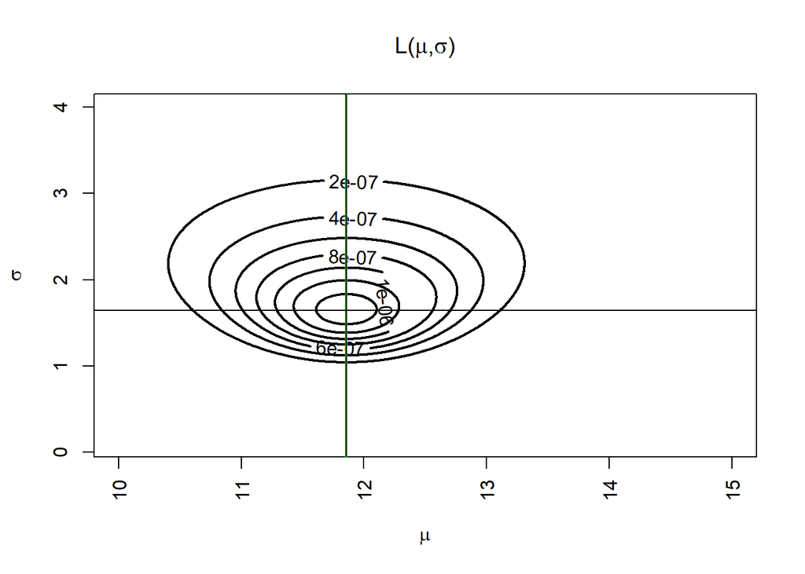

```
## $x
## [1] 10 12 13 15 12 11 10
##
## $coord
##      row col
## [1,] 372 396
##
## $maxl
## [1] 1.513619e-06
```

```r
y.list6 = c(10,12,13,15,12,11,10)

mymlnorm=function(x,mu,sig,...){
nmu=length(mu)
nsig=length(sig)
n=length(x)
zz=c()

lfun=function(x,m,p) log(dnorm(x,mean=m,sd=p))

for(j in 1:nsig){
  z=outer(x,mu,lfun,p=sig[j])
  y=apply(z,2,sum)
  zz=cbind(zz,y)
}

maxl=max(exp(zz))
coord=which(exp(zz)==maxl,arr.ind=TRUE)
maxlsig=apply(zz,1,max)

contour(mu,sig,exp(zz),las=3,xlab=expression(mu),ylab=expression(sigma),axes=TRUE,
main=expression(paste("L(",mu,",",sigma,")",sep="")),...)
mlx=round(mean(x),2)  # theoretical
mly=round(sqrt((n-1)/n)*sd(x),2)

abline(v=mean(x),lwd=2,col="Green")
muest=mu[coord[1]]
sigest=sig[coord[2]]
abline(v=muest, h=sigest)

return(list(x=x,coord=coord,maxl=maxl))

}

mymlnorm(x=y.list6,mu=seq(10,15,length=1000),sig=seq(0.1,4,length=1000),lwd=2,labcex=1)
```

# Task 7, Beta Distribution

[figure not shown]

```r
sam= rbeta(30,shape1=3,shape2=4)

mymlbeta=function(x,alpha,beta,...){
na=length(alpha)
nb=length(beta)
n=length(x)
zz=c()

lfun=function(x,a,b) log(dbeta(x,shape1=a,shape2=b))

for(j in 1:nb){
  z=outer(x,alpha,lfun,b=beta[j]) # z a matrix
  y=apply(z,2,sum)
  zz=cbind(zz,y)
}

maxl=max(exp(zz))
coord=which(exp(zz)==maxl,arr.ind=TRUE)
aest=alpha[coord[1]]
best=beta[coord[2]]

contour(alpha,beta,exp(zz),las=3,xlab=expression(alpha),ylab=expression(beta),axes=TRUE,
main=expression(paste("L(",alpha,",",beta,")",sep="")),...)

abline(v=aest, h=best)
points(aest,best,pch=19)
axis(4,best,round(best,2),col="Red")
axis(3,aest,round(aest,2),col="Red")

invisible(list(x=x,coord=coord,maxl=maxl,maxalpha=aest,maxbeta=best))

}

gri = matrix(1:12, nrow = 4, byrow =T)
layout(gri)

alphaq7 = c()
betaq7 = c()

for (res in 1:12){

  samResample = sample(sam, 30, replace = T)
  obj = mymlbeta(x=samResample,alpha=seq(1,6,length=100),beta=seq(1,6,length=100),lwd=2,labcex=1)
  alphaq7 = append(obj$maxalpha, alphaq7)
  betaq7 = append(obj$maxbeta, betaq7)

}
```

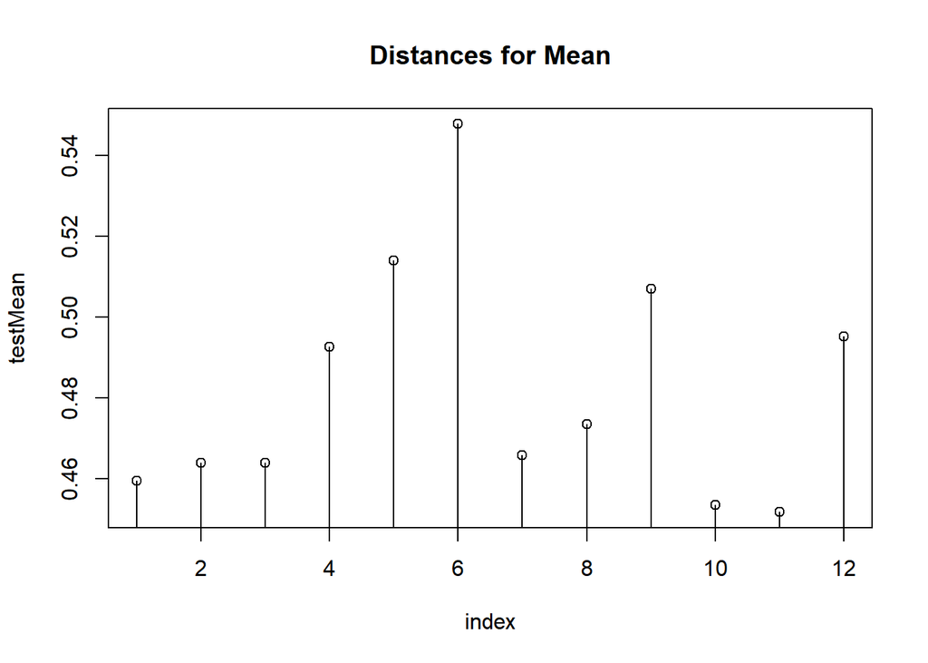

```r
index = 1:12

meanBeta = function(a,b){
  give = a/(a+b)
  return(give)
}

varBeta = function(a,b){
  give = (a*b)/((a+b)^2 * (a + b + 1))
  return(give)
}

trueMean = meanBeta(3,4)
trueVar = varBeta(3,4)

testMean = meanBeta(alphaq7, betaq7)
testVar = varBeta(alphaq7, betaq7)

plot(index, testMean, main = 'Distances for Mean')
lines(index, rep(trueMean, length(testMean)), col = '#2316B3', lw = 4)
segments(index, testMean, index, rep(trueMean, length(testMean)))
```

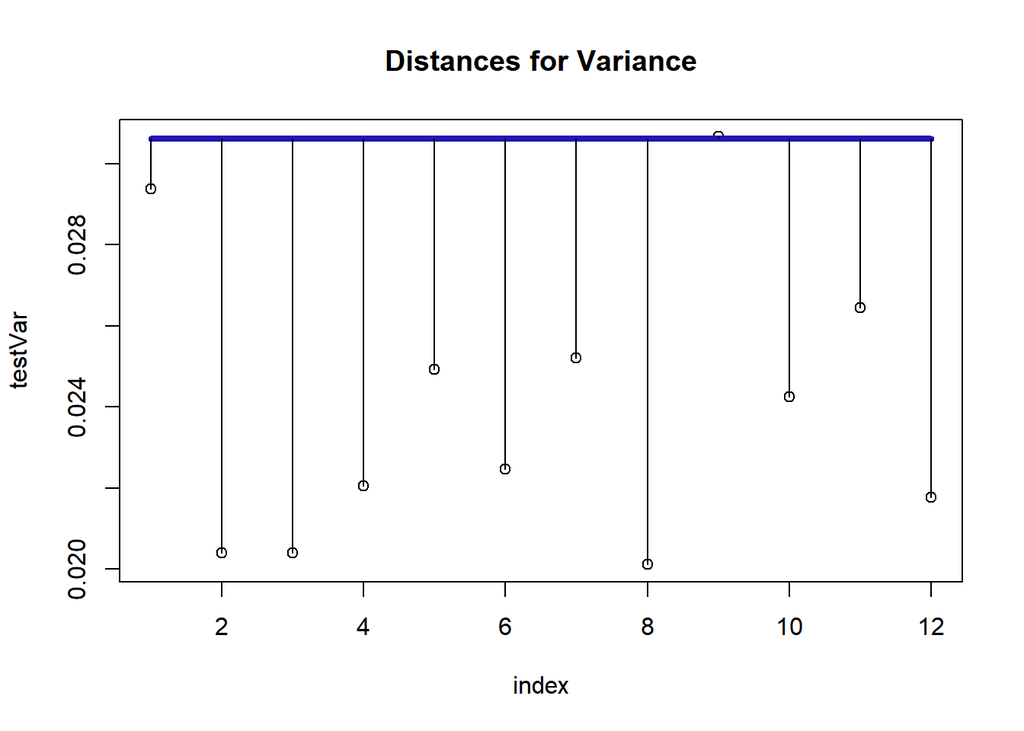

```r
plot(index, testVar, main = 'Distances for Variance')
lines(index, rep(trueVar, length(testVar)), col = '#2316B3', lw = 4)
segments(index, testVar, index, rep(trueVar, length(testVar)))
```

# Task 8, Package

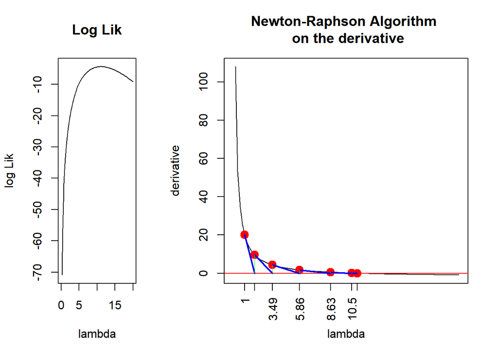

```
## $x
## [1]  1.000000  1.909450  3.485981  5.862937  8.626257 10.498288 10.978704
## [8] 11.000011 11.000000
##
## $y
## [1]  1.999999e+01  9.521638e+00  4.310991e+00  1.752385e+00  5.503529e-01
## [6]  9.557973e-02  3.879450e-03 -2.004619e-06 -2.664535e-09
```

```r
library(math4753)
myNRML(x0=1,delta=0.000001,llik=function(x) log(dpois(12,x)*dpois(10,x)),xrange=c(0,20),parameter="lambda" )
```